# Tutorial 2

Pierre Pinson

2023-10-15

## R Markdown

This is an [R Markdown](http://rmarkdown.rstudio.com) Notebook for the Tutorial 2 of the course “From Data to Product”. When you execute code within the notebook, the results appear beneath the code.

# Activity 1: Visualising the population of England

## Step 1

The variables that we have include: catgorical variables organised as a hierarchy (county -> regions -> England), and a numeric variable (population). It looks like we could use dendograms, treemaps and cirular packing visualisations for such data. Maybe others could also fit, but these seem to be most relevant.

## Step 2

Following the advice from the webpage indicated, here is the code I produced to scrape data from that wikipedia page

```r
# Libraries needed to clean data
library(tidyverse)
library(lubridate)
library(janitor)
# Libraries needed to scrape data
library(rvest)
library(httr)
library(polite)

# Provide the url of the wikipedia page to be scraped
url <- "https://en.wikipedia.org/wiki/Counties_in_England_by_population"

# Get access to the page at specific url
url_bow <- polite::bow(url)
url_bow
```

```
## <polite session> https://en.wikipedia.org/wiki/Counties_in_England_by_population
##     User-agent: polite R package
##     robots.txt: 456 rules are defined for 33 bots
##    Crawl delay: 5 sec
##   The path is scrapable for this user-agent
```

```r
# Scrape from url to get an html object, focusing on specific table
ind_html <-
  polite::scrape(url_bow) %>%  # scrape web page
  rvest::html_nodes("table.wikitable") %>% # pull out specific table
  rvest::html_table(fill = TRUE)

# Convert html to data frame
mydata <-
  ind_html[[1]] %>%
  clean_names()
```

## Step 3

Considering the 3 points of improvement mentioned in the Tutorial description, we end up with the following code, so that we both scrape the data and make it ready for good use:

```r
# Libraries needed to clean data
library(tidyverse)
library(lubridate)
library(janitor)

# Libraries needed to scrape data
library(rvest)
library(httr)
library(polite)

# Provide the url of the wikipedia page to be scraped
url <- "https://en.wikipedia.org/wiki/Counties_in_England_by_population"

# Get access to the page at specific url
url_bow <- polite::bow(url)
url_bow
```

```
## <polite session> https://en.wikipedia.org/wiki/Counties_in_England_by_population
##     User-agent: polite R package
##     robots.txt: 456 rules are defined for 33 bots
##    Crawl delay: 5 sec
##   The path is scrapable for this user-agent
```

```r
# Scrape from url to get an html object, focusing on specific table
ind_html <-
  polite::scrape(url_bow) %>%  # scrape web page
  rvest::html_nodes("table.wikitable") %>% # pull out specific table
  rvest::html_table(fill = TRUE)

# Convert html to data frame
mydata <-
  ind_html[[1]] %>%
  clean_names()

# Convert the actual data from type character to numeric
mydata$total_population <- as.numeric(gsub(",", "", mydata$total_population))

# Mistake with North Yorkshire to be corrected...
mydata$region[15] <- mydata$region[10]
```

## Step 4

It is fairly straightforward to use the code from the treemap page I indicated you. Here how it looks like if aiming to produce a treemap for the population of England:

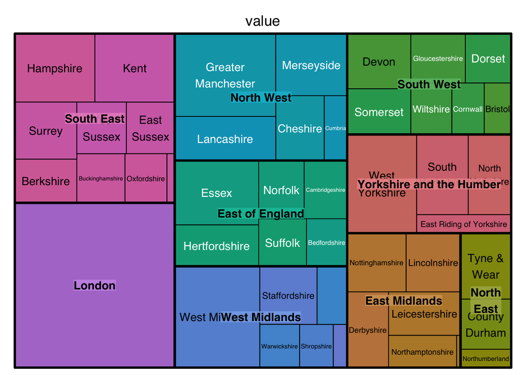

```r
# library
library(treemap)

# Build Dataset
group <- mydata$region
subgroup <- mydata$county
value <- mydata$total_population
data <- data.frame(group,subgroup,value)

# treemap
treemap(data,
        index=c("group","subgroup"),
        vSize="value",
        type="index"
        )
```

## Step 5

Let us look at the documentation for treemap now, and make it nicer. I also save it as a png.

```r
# library
library(treemap)

# Build Dataset
group <- mydata$region
subgroup <- mydata$county
value <- mydata$total_population
data <- data.frame(group,subgroup,value)

# treemap
png("England-population-treemap.png",width=1000, height=1000)
p <- treemap(data,
        index=c("group","subgroup"),
        vSize="value",
        type="index",
        title="England - population per region and county", # add title
        algorithm = "squarified", # I prefer this algorithm to produce the treemap
        fontsize.title = 36, # font siz for the title
        fontsize.labels=c(32,15),   # size of labels. Give the size per level of
                                    # aggregation: size for group, size for
                                    # subgroup, sub-subgroups...
        fontcolor.labels=c("white","lightgrey"), # Color of labels
        fontface.labels=c(2,1), # Font of labels: 1,2,3,4 for normal, bold,
                                # italic, bold-italic...
        bg.labels=c("transparent"),
        border.col=c("black","grey40"), # Color of borders of groups, of
                                        # subgroups, of subsubgroups ....
        border.lwds=c(7,2) # Width of borders (we need 2 values)
)
dev.off()
```

## Step 6

After looking at the page indicated for the circular packing visualisation, here is the code I produced (playing a bit with the colours, and saving it as an html widget):

```r
# Libraries
library(tidyverse)
library(hrbrthemes)
library(circlepackeR)
library(data.tree)
library(htmlwidgets)

# Change the format. This use the data.tree library. This library needs a column that looks like root/group/subgroup/..., so I build it
mydata$pathString <- paste("England", mydata$region, mydata$county, sep = "/")
population <- as.Node(mydata)

# You can custom the minimum and maximum value of the color range.
p <- circlepackeR(population,
                  size = "total_population",
                  color_min = "hsl(52,80%,80%)",
                  color_max = "hsl(148,30%,40%)")
saveWidget(p, file="England-population-interactive-circularpacking.html")
```

# Activity 2: Visualising summary statistics for weather data

## Step 1

We start by loading the data directly from the url provided:

```r
WeatherData <- read.csv("http://pierrepinson.com/wp-content/uploads/2023/10/Heathrow-weather-data-1948-2022.csv", header=TRUE)
```

## Step 2

We extract the minimum and maximum temperature vectors:

```r
t.min <- WeatherData$tmin
t.max <- WeatherData$tmin
```

## Step 2

We extract the minimum and maximum temperature vectors, and reshape them:

```r
tmin.mat <- WeatherData$tmin
tmax.mat <- WeatherData$tmax
dim(tmin.mat) <- c(12, length(tmin.mat)/12)
dim(tmax.mat) <- c(12, length(tmax.mat)/12)
```

## Step 3

We calculate the row averages to get the mean temperature statistics per month:

```r
tmin.mean <- rowMeans(tmin.mat)
tmax.mean <- rowMeans(tmax.mat)
```

Now, let’s calculate the standard deviation for the month of January:

```r
tmin.std.jan <- sd(tmin.mat[1,])
tmax.std.jan <- sd(tmax.mat[1,])
print(c(tmin.std.jan,tmax.std.jan))
```

```
## [1] 1.731871 1.835339
```

Then, we use the function apply to calculate standard deviation values for all months at once

```r
tmin.std <- apply(tmin.mat,1,sd)
tmax.std <- apply(tmax.mat,1,sd)
tmin.std
```

```
##  [1] 1.731871 1.815276 1.488904 1.202202 1.144974 1.062976 1.132633 1.185080
##  [9] 1.198352 1.528233 1.551868 1.800225
```

```r
tmax.std
```

```
##  [1] 1.835339 2.133839 1.860812 1.688214 1.613956 1.730705 2.111972 1.862989
##  [9] 1.459220 1.473376 1.315833 1.746169
```

In principle, higher standard deviation values indicate higher variability. Here, the variability of both minimum and maximum temperatures seems to be highest in February.

## Step 4

We can first look at the documentation for the quantile function

```r
?quantile
```

Now, let’s calculate quantiles for all months at one, and for both min and max temperatures:

```r
tmin.ql <- apply(tmin.mat,1,quantile,0.05)
tmax.ql <- apply(tmax.mat,1,quantile,0.05)
tmin.qu <- apply(tmin.mat,1,quantile,0.95)
tmax.qu <- apply(tmax.mat,1,quantile,0.95)
```

## Step 5

We re-use the code from Tutorial 1 as a basis, which we extend to have the shaded areas, with polygon:

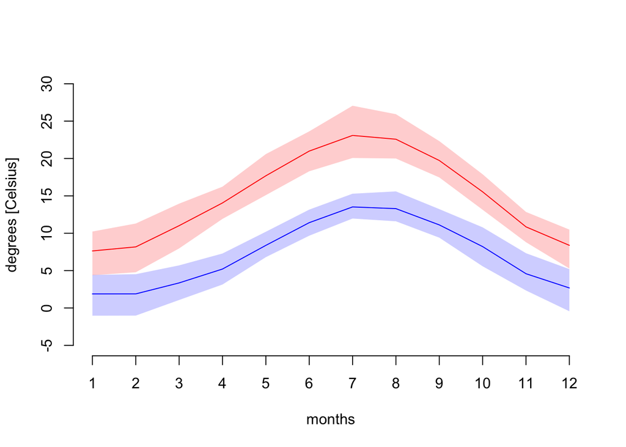

```r
tt <- seq(1,12,1)
tt.b <- c(tt,rev(tt)) # x-coordinates for the points defining our polygon area
tmin.b <- c(tmin.ql,rev(tmin.qu)) # y-coordinates for the points defining our
                                  # polygon area (tmin)
tmax.b <- c(tmax.ql,rev(tmax.qu)) # y-coordinates for the points defining our
                                  # polygon area (tmax)

plot(tmin.mean, type="l", col="blue", ylim=c(-5,30), xlab="months",
     ylab="degrees [Celsius]", axes=FALSE)
par(new=TRUE)
plot(tmax.mean, type="l", col="red", ylim=c(-5,30), xlab="", ylab="", axes=FALSE)
axis(1, seq(1,12,1))
axis(2, seq(-5,30,5))
par(new=TRUE)
polygon(tt.b,tmin.b,col=rgb(0,0,1,0.2),ylim=c(-5,30),xlab="",ylab="", border=NA)
par(new=TRUE)
polygon(tt.b,tmax.b,col=rgb(1,0,0,0.2),ylim=c(-5,30),xlab="",ylab="", border=NA)
```

```r
#legend(1,25, c("min T", "max T"), lty=c(1,1), col=c("blue", "red"))
```

These envelopes tell that 90% of the minimum and maximum temperatures observed over the period 1948-2022 fall within these ranges. For the values that are not within that range, half of them are below the lower bound of the envelope, and half of them are above the upper bound of the envelope. These represent the 5% lower and upper tail of the temperature distributions (min and max).

# Activity 3: Moving on with R Shiny

The solutions to the exercises in the “Basic reactivity” chapter are provided below.

## Exercise 1

In the first case, there are actually 2 problems. Firstly, “name” is not the right variable to use in the server block. It is something that comes as an input, and hence should be input$name. Simlarly, for "greeting", it is an output, and hence should be output$greeting instead.

```r
library(shiny)
ui <- fluidPage(
  textInput("name", "What's your name?"),
  textOutput("greeting")
)

server1 <- function(input, output, server) {
  output$greeting <- renderText(paste0("Hello ", input$name))
}
shinyApp(ui,server1)
```

Shiny applications not supported in static R Markdown documents

In the second case, the issue is to separate the construction of the output in 2 parts (i.e., first define greeting and then have it as part of render text). It should directly be as in the above. And, in the 3rd case, there is just a typo in “greeting” (spelled “greting” instead).

## Exercise 2

Here are the 3 reactive graphs

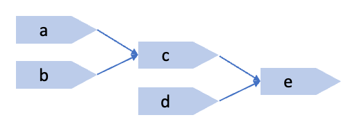

Reactive graph 1.

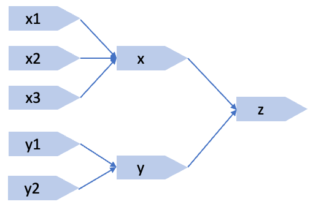

Reactive graph 2.

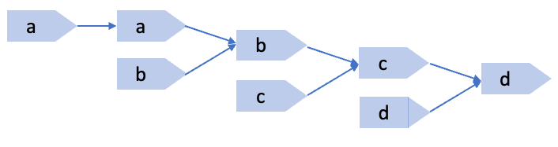

Reactive graph 3.

## Exercise 3

The code will fail since the name of variables is also a name for R functions. Then, R will be confused…

# Activity 4

## Step 1

The solution is available in app-weather-statistics-v1.R

## Step 2

The solution is available in app-weather-statistics-v2.R

## Step 3

The solution is available in app-weather-statistics-v3.R

## Step 4

The solution is available in app-weather-statistics-v4.R

## Step 5

The solution is available in app-weather-statistics-v5.R